# Project_html_212699581_207664996

## Introduction:

In the realm of financial markets, understanding the patterns and dynamic of stock prices is of paramount importance in order to blossom in this realm.  
The stock price of a company reflects not only its intrinsic value but also the collective perception of its future prospects. In this context, the analysis of stock price time series data becomes a crucial endeavor, offering insights into market trends, investor behavior, and potential forecasting opportunities.

For our time series analysis project, we have chosen to delve into the world of Apple Inc., one of the most iconic and influential companies in the technology field. the dataset we have selected spance over a long period of time, capturing the rise and the fluctuations in Apple's stock price over time.

In this part of the project, we will conduct a comprehensive preliminary analysis of the Apple stock price dataset. We will present the patterns, trends and seasonality ingerent in the data. we will be doing this through graph and visualization.

```python
import pandas as pd  # For data manipulation
import numpy as np  # For numerical operations

# Visualization libraries
import matplotlib.pyplot as plt  # For basic plotting
import seaborn as sns  # For heatmap and enhanced visualizations
from matplotlib import dates as mpl_dates  # For handling dates in plots

# Plotly for interactive visualizations
import plotly.express as px
import plotly.graph_objects as go

# Additional Plotly utilities
from plotly.subplots import make_subplots

# For 3D plotting in Matplotlib
from mpl_toolkits.mplot3d import Axes3D
```

```python
df = pd.read_csv('AAPL_EXO.csv')  # Load your dataset
```

```python
df.shape
```

```
(10943, 13)
```

```python
new_df = df.dropna(subset=['Date', 'Open', 'High', 'Low', 'Close', 'Adj Close', 'Volume'])
```

```python
new_df.columns
```

```
Index(['Date', 'Open', 'High', 'Low', 'Close', 'Adj Close', 'Volume',
       'NDXT Open', 'NDXT High', 'NDXT Low', 'NDXT Close', 'NDXT Adj Close',
       'NDXT Volume'],
      dtype='object')
```

```python
new_df.shape
```

```
(10943, 13)
```

```python
new_df['Date'] = pd.to_datetime(df['Date'])
new_df.set_index('Date', inplace=True)
```

```python
# Convert data types for numerical analysis if not already done
# It's essential for accurate calculations
new_df['Open'] = pd.to_numeric(new_df['Open'], errors='coerce')
new_df['High'] = pd.to_numeric(new_df['High'], errors='coerce')
new_df['Low'] = pd.to_numeric(new_df['Low'], errors='coerce')
new_df['Close'] = pd.to_numeric(new_df['Close'], errors='coerce')
new_df['Adj Close'] = pd.to_numeric(new_df['Adj Close'], errors='coerce')
new_df['Volume'] = pd.to_numeric(new_df['Volume'], errors='coerce')

# Calculate descriptive statistics
descriptive_stats = new_df.describe()

# Display the descriptive statistics
print(descriptive_stats)
```

```
               Open          High           Low         Close     Adj Close  \
count  10943.000000  10943.000000  10943.000000  10943.000000  10943.000000
mean      21.353170     21.583253     21.131446     21.366237     20.729636
std       44.133581     44.607098     43.688894     44.167548     43.959537
min        0.049665      0.049665      0.049107      0.049107      0.038329
25%        0.296875      0.303571      0.289063      0.296875      0.244296
50%        0.520089      0.531250      0.513214      0.521786      0.430849
75%       19.624643     19.789286     19.322142     19.508393     17.166773
max      198.020004    199.619995    197.000000    198.110001    197.857529

             Volume    NDXT Open    NDXT High     NDXT Low   NDXT Close  \
count  1.094300e+04  2996.000000  2996.000000  2996.000000  2996.000000
mean   3.193633e+08  1681.090972  1692.564566  1668.964546  1681.775694
std    3.357951e+08   791.414398   793.365083   788.929549   791.901506
min    0.000000e+00   535.960022   552.580017   516.219971   525.919983
25%    1.142400e+08  1098.930024  1106.707489  1088.287476  1098.574982
50%    2.070880e+08  1396.375000  1405.834961  1387.830017  1397.380005
75%    3.995306e+08  2218.097595  2231.672485  2206.552491  2218.407471
max    7.421641e+09  4223.399902  4229.700195  4203.660156  4227.680176

       NDXT Adj Close  NDXT Volume
count     2996.000000       2996.0
mean      1681.775694          0.0
std        791.901506          0.0
min        525.919983          0.0
25%       1098.574982          0.0
50%       1397.380005          0.0
75%       2218.407471          0.0
max       4227.680176          0.0
```

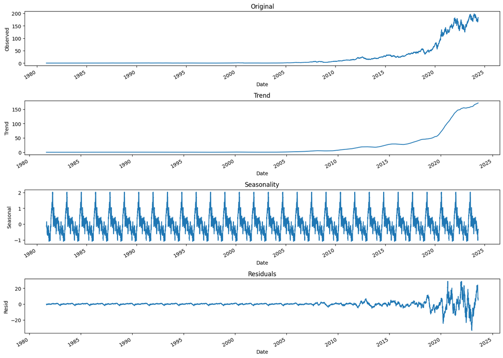

```python
from statsmodels.tsa.seasonal import seasonal_decompose
import matplotlib.pyplot as plt

# Decompose the time series
decomposition = seasonal_decompose(new_df['Close'], model='additive', period=365) # or 'multiplicative', depending on your data

# Plot the decomposed components of the time series
fig, (ax1, ax2, ax3, ax4) = plt.subplots(4, 1, figsize=(14, 10)) # You can adjust the size as needed

# Plot the original time series, trend, seasonal, and residual components
decomposition.observed.plot(ax=ax1, title='Original')
ax1.set_ylabel('Observed')

decomposition.trend.plot(ax=ax2, title='Trend')
ax2.set_ylabel('Trend')

decomposition.seasonal.plot(ax=ax3, title='Seasonality')
ax3.set_ylabel('Seasonal')

decomposition.resid.plot(ax=ax4, title='Residuals')
ax4.set_ylabel('Resid')

# Adjust layout
plt.tight_layout()
plt.show()
```

### Original:

The first plot shows the original time series data for the AAPL closing stock prices. It demonstrates a long-term upward trend with some fluctuations over time. There is a notable acceleration in price increase in the latter part of the series, indicating periods of rapid growth.

### Seasonality:

The third plot shows the seasonal component of the time series. It exhibits the regular and periodic fluctuations within the time series data that repeat over a specific interval. In this case, the fluctuations seem quite consistent, suggesting a stable seasonal pattern. The scale of seasonality is relatively small compared to the overall trend, which is typical for stock data that doesn't typically have strong seasonality like retail or agricultural sectors might.

### Residuals:

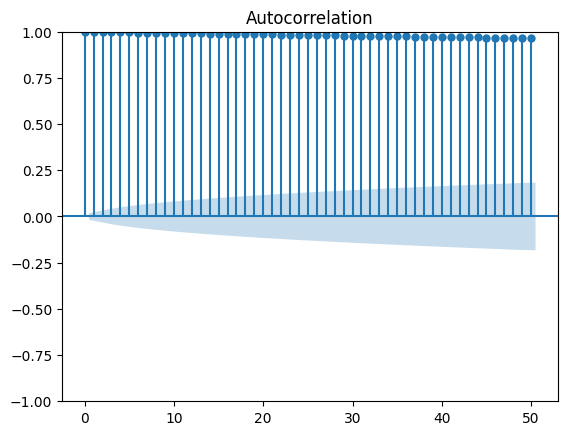

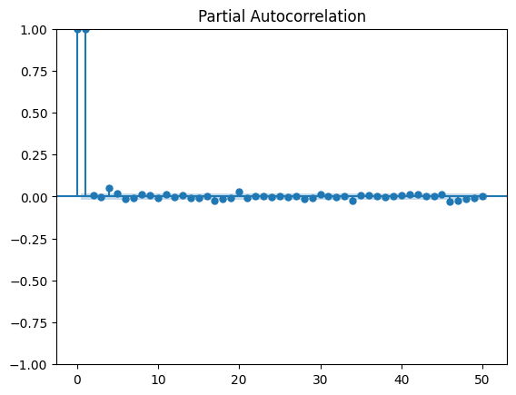

```python
from statsmodels.graphics.tsaplots import plot_acf, plot_pacf

plot_acf(new_df['Close'], lags=50)
plt.show()

plot_pacf(new_df['Close'], lags=50)
plt.show()
```

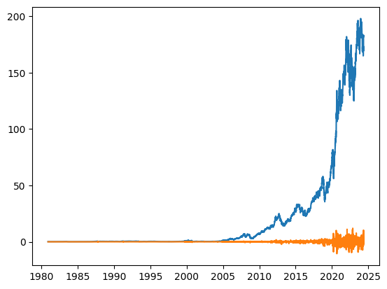

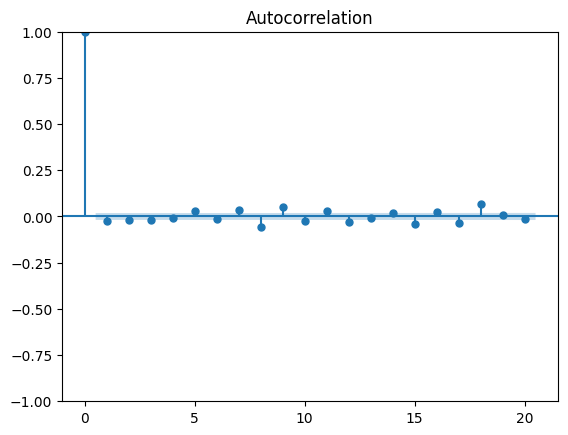

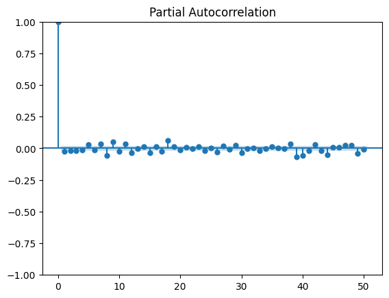

```python
plt.plot(new_df.index, new_df['Close'])
plt.plot(new_df.index, new_df['Close'].diff())

plot_acf(new_df['Close'].diff().dropna(), lags=20)
plt.show()

plot_pacf(new_df['Close'].diff().dropna(), lags=50)
plt.show()
```

### Partial Autocorrelation Function (PACF) Plot:

This plot shows the partial correlation of a time series with its own lagged values, controlling for the values of the time series at all shorter lags. It helps identify the order of an autoregressive (AR) model. The PACF plot here has a significant spike at lag 1 and possibly at lag 2, and then it cuts off sharply, which is indicative of an AR(1) or AR(2) process.

### Autocorrelation Function (ACF) Plot:

The ACF plot shows the correlation between the time series and its lagged values. The ACF plot provided has a gradual decline in correlation values as the lag increases. This pattern typically suggests that the underlying time series is not stationary and may contain a trend or seasonal component. The slow decay also indicates that an AR model might be appropriate. Based on these observations, here are the conclusions:

Non-Stationarity: The ACF plot indicates non-stationarity due to the gradual decline in correlation values rather than a sharp cut-off. Before fitting a model, you might need to difference the series to make it stationary or consider detrending or deseasonalizing the data.

Model Suggestion: The PACF plot suggests that an AR(1) or AR(2) model may be appropriate for the data, as indicated by the significant spikes at lags 1 and possibly 2.

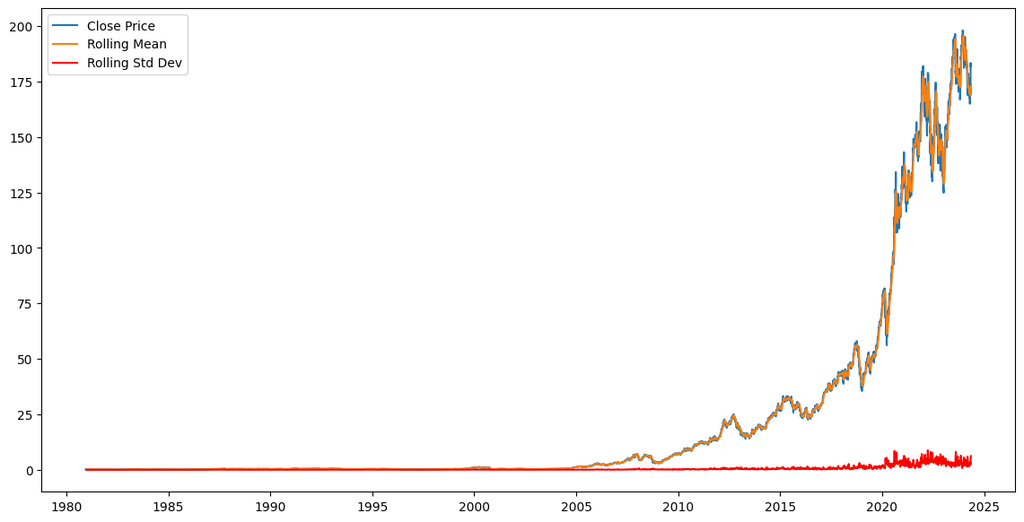

```python
rolling_window = 12 # Example for monthly rolling window
new_df['rolling_mean'] = new_df['Close'].rolling(window=rolling_window).mean()
new_df['rolling_std'] = new_df['Close'].rolling(window=rolling_window).std()

plt.figure(figsize=(14, 7))
plt.plot(new_df.index, new_df['Close'], label='Close Price')
plt.plot(new_df.index, new_df['rolling_mean'], label='Rolling Mean')
plt.plot(new_df.index, new_df['rolling_std'], label='Rolling Std Dev', color='red')
plt.legend()
plt.show()
```

#### Trend:

The closing price shows a clear upward trend over time. There are periods of relative stability as well as periods of rapid increase, particularly notable in the latter part of the chart.

#### Volatility:

The rolling standard deviation appears to increase with time, especially during the periods when the stock price also increases significantly. This indicates higher volatility during these periods.

#### Mean:

The rolling mean, which is a moving average, increases over time, tracking closely with the upward trend of the closing prices. This suggests a persistent long-term upward trend in the stock price.

#### Stationarity:

The fact that both the rolling mean and rolling standard deviation increase over time suggests that the time series is not stationary. A stationary time series has constant mean and variance over time. Non-stationarity is an important aspect to consider when modeling time series data as most time series models require the data to be stationary.

#### Potential Transformations:

Given the non-stationary nature of the data, differencing or logarithmic transformation might be required to stabilize the mean and variance before fitting a time series model.

#### Periods of Rapid Change:

There are certain periods where the stock price increases rapidly, potentially corresponding to key events or product launches. These would be interesting to investigate further, perhaps with an event study.

#### Long-Term Investment:

For long-term investors, the general upward trend might be interpreted positively, but one should also consider the increasing volatility and potential risks associated with it.

In conclusion, while the historical stock price data shows a strong upward trend suggesting a good long-term performance, the increasing volatility indicates that there may be higher risks, particularly in the short term. Before using this data for forecasting, it would be crucial to stabilize the variance and possibly detrend the series to ensure any models applied are appropriate and the resulting forecasts are reliable.

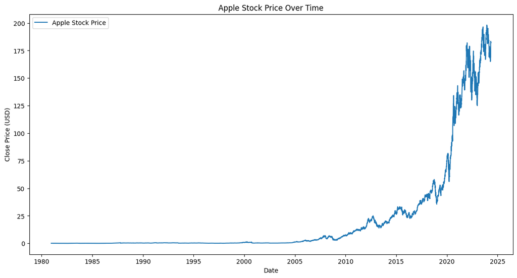

```python
plt.figure(figsize=(14, 7))
plt.plot(new_df.index, df['Close'], label='Apple Stock Price')
plt.title('Apple Stock Price Over Time')
plt.xlabel('Date')
plt.ylabel('Close Price (USD)')
plt.legend()
plt.show()
```

```python
# Ensure the index is a datetime type for resampling
new_df.index = pd.to_datetime(new_df.index)

# Calculate annual returns based on 'Adj Close'
annual_returns = new_df['Adj Close'].resample('Y').last().pct_change()
```

## High-Low Price Range Each Year

Showcasing the range of stock prices within each year can illustrate volatility and trading opportunities.

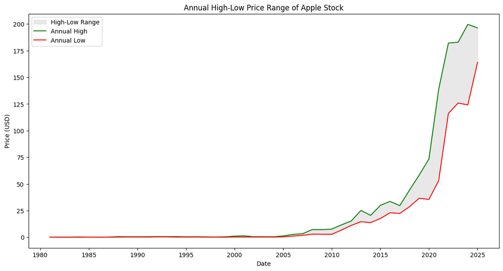

```python
# Resample data annually to find max and min prices
annual_high = new_df['High'].resample('Y').max()
annual_low = new_df['Low'].resample('Y').min()

plt.figure(figsize=(14, 7))
plt.fill_between(annual_high.index, annual_low, annual_high, color='lightgray', alpha=0.5, label='High-Low Range')
plt.plot(annual_high.index, annual_high, label='Annual High', color='green')
plt.plot(annual_low.index, annual_low, label='Annual Low', color='red')
plt.title('Annual High-Low Price Range of Apple Stock')
plt.xlabel('Date')
plt.ylabel('Price (USD)')
plt.legend()
plt.show()
```

## Moving Averages

Moving averages are a foundational analysis tool, smoothing out price data over a specific period and helping to identify trends.

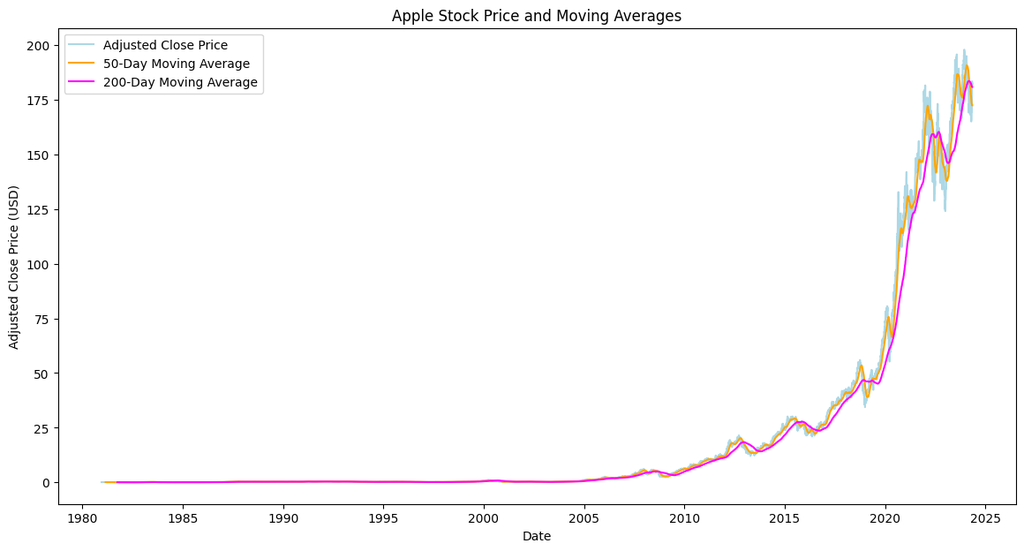

```python
# Calculate 50-day and 200-day moving averages
new_df['50_MA'] = new_df['Adj Close'].rolling(window=50).mean()
new_df['200_MA'] = new_df['Adj Close'].rolling(window=200).mean()

plt.figure(figsize=(14, 7))
plt.plot(new_df.index, new_df['Adj Close'], label='Adjusted Close Price', color='lightblue')
plt.plot(new_df.index, new_df['50_MA'], label='50-Day Moving Average', color='orange')
plt.plot(new_df.index, new_df['200_MA'], label='200-Day Moving Average', color='magenta')
plt.title('Apple Stock Price and Moving Averages')
plt.xlabel('Date')
plt.ylabel('Adjusted Close Price (USD)')
plt.legend()
plt.show()
```

## PART 2 - Model Fitting

After exploring the data and trying to find patterns, we decided to delve into predicting the Close price of the apple stock. Following previous exploration, we suggest that the model which best fits the Close price could be AR(2) or AR(1), but in order to find the best model we're going to test different SARIMA models and also Prophet(Below - every model and it's parameters in addition to the explanation of choice). Also, after we conducted research about the relevancy of the years in our dataset, we conculded that the behaviour of the stock Close price before the year 2007 (The First Release of the iPhone) is not relevant since the Close prices was significantly low compared to today's stock price, So we chose to consider the data from a year before (2006) and on.

```python
new_df
```

| Date | Open | High | Low | Close | Adj Close | Volume | NDXT Open | NDXT High | NDXT Low | NDXT Close | NDXT Adj Close | NDXT Volume | rolling_mean | rolling_std | 50_MA | 200_MA |
| --- | --- | --- | --- | --- | --- | --- | --- | --- | --- | --- | --- | --- | --- | --- | --- | --- |
| 1980-12-12 | 0.128348 | 0.128906 | 0.128348 | 0.128348 | 0.100178 | 469033600 | NaN | NaN | NaN | NaN | NaN | NaN | NaN | NaN | NaN | NaN |
| 1980-12-15 | 0.122210 | 0.122210 | 0.121652 | 0.121652 | 0.094952 | 175884800 | NaN | NaN | NaN | NaN | NaN | NaN | NaN | NaN | NaN | NaN |
| 1980-12-16 | 0.113281 | 0.113281 | 0.112723 | 0.112723 | 0.087983 | 105728000 | NaN | NaN | NaN | NaN | NaN | NaN | NaN | NaN | NaN | NaN |
| 1980-12-17 | 0.115513 | 0.116071 | 0.115513 | 0.115513 | 0.090160 | 86441600 | NaN | NaN | NaN | NaN | NaN | NaN | NaN | NaN | NaN | NaN |
| 1980-12-18 | 0.118862 | 0.119420 | 0.118862 | 0.118862 | 0.092774 | 73449600 | NaN | NaN | NaN | NaN | NaN | NaN | NaN | NaN | NaN | NaN |
| ... | ... | ... | ... | ... | ... | ... | ... | ... | ... | ... | ... | ... | ... | ... | ... | ... |
| 2024-05-01 | 169.580002 | 172.710007 | 169.110001 | 169.300003 | 169.300003 | 50383100 | NaN | NaN | NaN | NaN | NaN | NaN | 168.625000 | 2.270074 | 172.5940 | 181.061527 |
| 2024-05-02 | 172.509995 | 173.419998 | 170.889999 | 173.029999 | 173.029999 | 94214900 | NaN | NaN | NaN | NaN | NaN | NaN | 168.929166 | 2.600863 | 172.4082 | 180.961837 |
| 2024-05-03 | 186.649994 | 187.000000 | 182.660004 | 183.380005 | 183.380005 | 163224100 | NaN | NaN | NaN | NaN | NaN | NaN | 170.210833 | 4.886537 | 172.3884 | 180.907075 |
| 2024-05-06 | 182.350006 | 184.199997 | 180.419998 | 181.710007 | 181.710007 | 78569700 | NaN | NaN | NaN | NaN | NaN | NaN | 171.433334 | 5.775366 | 172.3722 | 180.853773 |
| 2024-05-07 | 183.449997 | 184.899994 | 181.320007 | 182.399994 | 182.399994 | 77237500 | NaN | NaN | NaN | NaN | NaN | NaN | 172.883334 | 6.183212 | 172.3970 | 180.809848 |

10943 rows × 16 columns

```python
# Adjust Relevent Data rows
pred_data = new_df[(new_df.index.year >= 2006) & (new_df.index <= '2022-06-17')]
```

```python
# A dataset for comparing forecasts for current date interval
# not_clean_current_df = pd.read_csv('AAPL_2024.csv')
not_clean_current_df = new_df[new_df.index >= '2022-06-17']
current_df = not_clean_current_df.dropna(subset=['Open', 'High', 'Low', 'Close', 'Adj Close', 'Volume'])
# current_df['Date'] = pd.to_datetime(current_df['Date'])
# current_df.set_index('Date',inplace=True)
```

```python
new_df = new_df[new_df.index <= '2022-06-17']
```

### Components for our first model - ARIMA(1,1,1) :

Due to the sharp cutoff in PACF, we suggest AR(1) model then we set p=1. The quick drop-off of ACF and preliminary analysis could suggest a MA(1) could be tested, so we set q=1. Then we set differencing to 1 due to non-stationarity.

```
                               SARIMAX Results
==============================================================================
Dep. Variable:                  Close   No. Observations:                 4146
Model:               SARIMAX(1, 1, 1)   Log Likelihood               -6283.512
Date:                Thu, 09 May 2024   AIC                          12573.024
Time:                        16:31:52   BIC                          12592.013
Sample:                             0   HQIC                         12579.743
                               - 4146
Covariance Type:                  opg
==============================================================================
                 coef    std err          z      P>|z|      [0.025      0.975]
------------------------------------------------------------------------------
ar.L1          0.2112      0.085      2.484      0.013       0.045       0.378
ma.L1         -0.2705      0.084     -3.209      0.001      -0.436      -0.105
sigma2         1.2140      0.008    149.597      0.000       1.198       1.230
===================================================================================
Ljung-Box (L1) (Q):                   0.01   Jarque-Bera (JB):             67382.23
Prob(Q):                              0.93   Prob(JB):                         0.00
Heteroskedasticity (H):             205.61   Skew:                            -0.21
Prob(H) (two-sided):                  0.00   Kurtosis:                        22.75
===================================================================================

Warnings:
[1] Covariance matrix calculated using the outer product of gradients (complex-step).
```

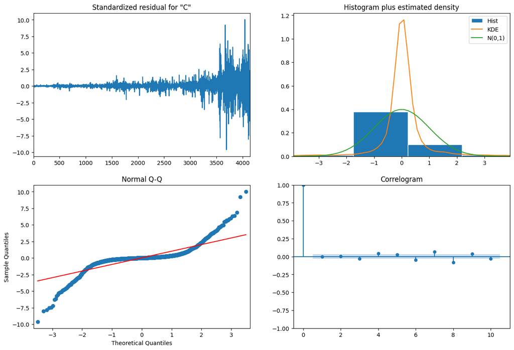

```
Forecast: 4146    131.494152
4147    131.480246
4148    131.477309
4149    131.476688
4150    131.476557
4151    131.476530
4152    131.476524
4153    131.476522
4154    131.476522
4155    131.476522
Name: predicted_mean, dtype: float64
```

```python
from statsmodels.tsa.statespace.sarimax import SARIMAX
# Train ARIMA model with parameters (p=1, d=1, q=0)
order = (1, 1, 1)  # ARIMA parameters: (p, d, q)
# seasonal_order = (1, 1, 1, 10)  # Seasonal parameters: (P, D, Q, S)

# data column we're going to predict
data = pred_data['Close']

# model = ARIMA(pred_data['Close'], order=order)
sarima10_model = SARIMAX(data, order=order)

fit_model = sarima10_model.fit()

# Print model summary
print(fit_model.summary())

# Plot residuals
fit_model.plot_diagnostics(figsize=(15, 10))
plt.show()

# Make predictions
forecast = fit_model.forecast(steps=10)  # Change steps to the desired forecast horizon

# Print forecast
print("Forecast:", forecast)
```

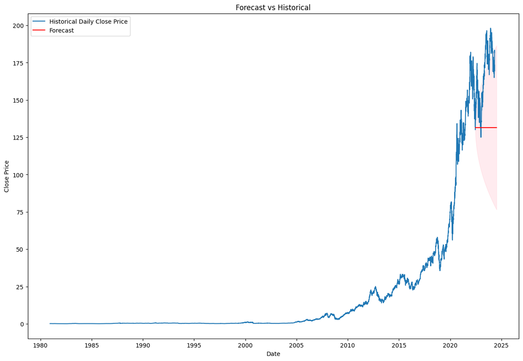

```python
periods = 252*3

forecast = fit_model.get_forecast(steps=periods)
# Get forecast values
forecast_sarima0_values = forecast.predicted_mean

# Get confidence intervals for the forecast
forecast_ci = forecast.conf_int()

# define last date in the dataset
last_date = new_df.index[-1]

# Create a date range for the forecast values, starting the day after the last_date
forecast_index = pd.date_range(start=last_date + pd.Timedelta(days=1), periods=periods, freq='D')

# Assume forecast_values is a Series or array from your SARIMA model forecast
forecast_sarima0_values.index = forecast_index

# Getting forecast confidence intervals
forecast_ci.index = forecast_index

# Plotting
plt.figure(figsize=(15, 10))
plt.plot(pd.concat([new_df['Close'],current_df['Close']],axis=0), label='Historical Daily Close Price')
plt.plot(forecast_sarima0_values.index, forecast_sarima0_values, color='red', label='Forecast')
plt.fill_between(forecast_sarima0_values.index,
                 forecast_ci.iloc[:, 0],
                 forecast_ci.iloc[:, 1], color='pink', alpha=0.3)

plt.title('Forecast vs Historical')
plt.xlabel('Date')
plt.ylabel('Close Price')
plt.legend()
plt.show()
```

### Components for our second model - SARIMA(1,1,1)(1,1,1)[63] :

#### Non-seasonal

Since the PACF showed a sharp cutoff after lag 1, that suggest AR(1) model then we set p=1. The quick drop-off of ACF could suggest a MA(1) could be tested, particularly if after differencing the ACF shows a spike at lag 1, the q=1. Then we set differencing to 1 due to non-stationarity.

#### Seasonal:

In stocks market and for daily information, we want to set seasonality to be the number of quarterly trading days in a year which is 252//4 = 63 as mentioned in this [page](https://en.wikipedia.org/wiki/Trading_day) and the rest of the data would be the same as the non-Seasonal.

```python
# With SEASONALITY
from statsmodels.tsa.statespace.sarimax import SARIMAX
# Setting SARIMAX according to the conclusions mentioned earlier
data = pred_data['Close']
sarima1_model = SARIMAX(data,
                order=(1, 1, 1),
                seasonal_order=(1, 1, 1, 252//4),
                enforce_stationarity=False,
                enforce_invertibility=False)
# enforce_stationarity=False and enforce_invertibility=False are
# helpful during model exploration, especially when the model diagnostics suggest non-invertibility or non-stationarity issues with the parameters
sarima1_results = sarima1_model.fit(disp=True)
```

```python
print(sarima1_results.summary())
```

```
                                     SARIMAX Results
==========================================================================================
Dep. Variable:                              Close   No. Observations:                 4146
Model:             SARIMAX(1, 1, 1)x(1, 1, 1, 63)   Log Likelihood               -6227.268
Date:                            Thu, 09 May 2024   AIC                          12464.535
Time:                                    16:52:22   BIC                          12496.027
Sample:                                         0   HQIC                         12475.696
                                           - 4146
Covariance Type:                              opg
==============================================================================
                 coef    std err          z      P>|z|      [0.025      0.975]
------------------------------------------------------------------------------
ar.L1         -0.3377      0.103     -3.271      0.001      -0.540      -0.135
ma.L1          3.4689      1.266      2.741      0.006       0.988       5.949
ar.S.L63       0.0294      0.008      3.826      0.000       0.014       0.044
ma.S.L63      -0.9488      0.005   -198.821      0.000      -0.958      -0.939
sigma2         0.1041      0.076      1.371      0.170      -0.045       0.253
===================================================================================
Ljung-Box (L1) (Q):                   0.10   Jarque-Bera (JB):             62653.89
Prob(Q):                              0.76   Prob(JB):                         0.00
Heteroskedasticity (H):             162.59   Skew:                            -0.25
Prob(H) (two-sided):                  0.00   Kurtosis:                        22.34
===================================================================================

Warnings:
[1] Covariance matrix calculated using the outer product of gradients (complex-step).
```

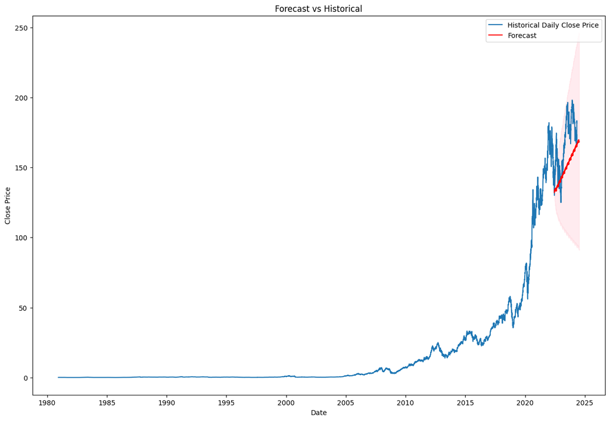

```python
periods = 252*3

forecast = sarima1_results.get_forecast(steps=periods)
# Get forecast values
forecast_sarima1_values = forecast.predicted_mean

# Get confidence intervals for the forecast
forecast_ci = forecast.conf_int()

# define last date in the dataset
last_date = new_df.index[-1]

# Create a date range for the forecast values, starting the day after the last_date
forecast_index = pd.date_range(start=last_date + pd.Timedelta(days=1), periods=periods, freq='D')

# Assume forecast_values is a Series or array from your SARIMA model forecast
forecast_sarima1_values.index = forecast_index

# Getting forecast confidence intervals
forecast_ci.index = forecast_index

# Plotting
plt.figure(figsize=(15, 10))
# plt.plot(new_df['Close'], label='Historical Daily Close Price')
plt.plot(pd.concat([new_df['Close'],current_df['Close']],axis=0), label='Historical Daily Close Price')
plt.plot(forecast_sarima1_values.index, forecast_sarima1_values, color='red', label='Forecast')
plt.fill_between(forecast_sarima1_values.index,
                 forecast_ci.iloc[:, 0],
                 forecast_ci.iloc[:, 1], color='pink', alpha=0.3)

plt.title('Forecast vs Historical')
plt.xlabel('Date')
plt.ylabel('Close Price')
plt.legend()
plt.show()
```

```python
print("Numerical Values Of our Second model forecast:")
print(forecast_sarima1_values)
```

```
Numerical Values Of our Second model forecast:
2022-06-18    132.063716
2022-06-19    132.383368
2022-06-20    132.728679
2022-06-21    133.080524
2022-06-22    133.491672
                 ...
2024-07-08    168.786301
2024-07-09    168.754260
2024-07-10    168.367646
2024-07-11    168.192380
2024-07-12    168.400450
Freq: D, Name: predicted_mean, Length: 756, dtype: float64
```

### Components for our third model - ARIMA(2,0,2) :

```python
# Without SEASONALITY
from statsmodels.tsa.statespace.sarimax import SARIMAX
# Setting SARIMAX according to the conclusions mentioned earlier
data = pred_data['Close']
sarima2_model = SARIMAX(data,
                order=(2, 0, 2),
                enforce_stationarity=False,
                enforce_invertibility=False)
# enforce_stationarity=False and enforce_invertibility=False are
# helpful during model exploration, especially when the model diagnostics suggest non-invertibility or non-stationarity issues with the parameters
sarima2_results = sarima2_model.fit()
```

```python
print(sarima2_results.summary())
```

```
                               SARIMAX Results
==============================================================================
Dep. Variable:                  Close   No. Observations:                 4146
Model:               SARIMAX(2, 0, 2)   Log Likelihood               -6277.560
Date:                Thu, 09 May 2024   AIC                          12565.119
Time:                        16:52:24   BIC                          12596.765
Sample:                             0   HQIC                         12576.317
                               - 4146
Covariance Type:                  opg
==============================================================================
                 coef    std err          z      P>|z|      [0.025      0.975]
------------------------------------------------------------------------------
ar.L1          0.1002      0.029      3.421      0.001       0.043       0.158
ar.L2          0.9008      0.029     30.738      0.000       0.843       0.958
ma.L1          0.8416      0.030     28.099      0.000       0.783       0.900
ma.L2         -0.0722      0.006    -12.478      0.000      -0.084      -0.061
sigma2         1.2118      0.008    144.492      0.000       1.195       1.228
===================================================================================
Ljung-Box (L1) (Q):                   0.00   Jarque-Bera (JB):             66208.97
Prob(Q):                              0.98   Prob(JB):                         0.00
Heteroskedasticity (H):             205.53   Skew:                            -0.35
Prob(H) (two-sided):                  0.00   Kurtosis:                        22.57
===================================================================================

Warnings:
[1] Covariance matrix calculated using the outer product of gradients (complex-step).
```

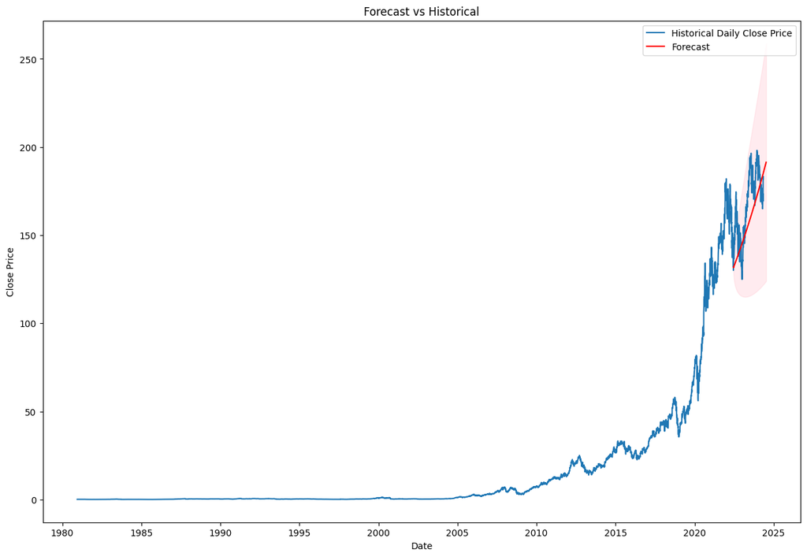

```python
periods = 252*3

forecast = sarima2_results.get_forecast(steps=periods)
# Get forecast values
forecast_sarima2_values = forecast.predicted_mean

# Get confidence intervals for the forecast
forecast_ci = forecast.conf_int()

# define last date in the dataset
last_date = new_df.index[-1]

# Create a date range for the forecast values, starting the day after the last_date
forecast_index = pd.date_range(start=last_date + pd.Timedelta(days=1), periods=periods, freq='D')

# Assume forecast_values is a Series or array from your SARIMA model forecast
forecast_sarima2_values.index = forecast_index

# Getting forecast confidence intervals
forecast_ci.index = forecast_index

# Plotting
plt.figure(figsize=(15, 10))
plt.plot(pd.concat([new_df['Close'],current_df['Close']],axis=0), label='Historical Daily Close Price')
# plt.plot(new_df['Close'], label='Historical Daily Close Price')
plt.plot(forecast_sarima2_values.index, forecast_sarima2_values, color='red', label='Forecast')
plt.fill_between(forecast_sarima2_values.index,
                 forecast_ci.iloc[:, 0],
                 forecast_ci.iloc[:, 1], color='pink', alpha=0.3)

plt.title('Forecast vs Historical')
plt.xlabel('Date')
plt.ylabel('Close Price')
plt.legend()
plt.show()
```

```python
print("Numerical Values Of our third model forecast:")
print(forecast_sarima2_values)
```

```
Numerical Values Of our third model forecast:
2022-06-18    131.653577
2022-06-19    131.589873
2022-06-20    131.771316
2022-06-21    131.732104
2022-06-22    131.891618
                 ...
2024-07-08    190.974706
2024-07-09    191.069449
2024-07-10    191.164240
2024-07-11    191.259078
2024-07-12    191.353962
Freq: D, Name: predicted_mean, Length: 756, dtype: float64
```

### Our fourth model: Prophet

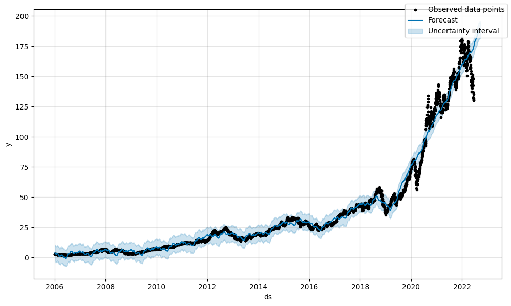

```python
from prophet import Prophet

# Assuming 'data' is the DataFrame with columns 'ds' (datetime) and 'y' (target variable)
# Rename the columns to match Prophet's requirements

data = pred_data.reset_index().rename(columns={'Date': 'ds', 'Close': 'y'})

# Initialize Prophet model
prophet_model = Prophet()

# Fit the model to the data
prophet_model.fit(data)

# Make future predictions
future = prophet_model.make_future_dataframe(periods=100)  # Adjust the number of future periods as needed
forecast = prophet_model.predict(future)

# Plot the forecast
fig = prophet_model.plot(forecast)
fig.legend()
```

```python
se = np.square(forecast.loc[:, 'yhat'] - data['y'])
se_mae = np.abs(forecast.loc[:, 'yhat'] - data['y'])

mse = np.mean(se)
mae = np.mean(se_mae)

rmse = np.sqrt(mse)

print('MAE of Prohpet: {}'.format(mae))
print('RMSE of Prophet: {}'.format(rmse))


# Get the in-sample predictions
in_sample_predictions = prophet_model.predict(data)

# Calculate residuals
residuals = data['y'] - in_sample_predictions['yhat']

# Calculate the effective number of parameters (p_eff)
p_eff = prophet_model.params['k'].shape[0]

# Calculate the log likelihood
log_likelihood = -0.5 * (np.log(2 * np.pi * residuals.std()) + (residuals ** 2 / residuals.var()).sum())

# Calculate the penalized log likelihood
penalized_log_likelihood = log_likelihood - p_eff

# Calculate WAIC
waic = -2 * penalized_log_likelihood + 2 * p_eff

print("WAIC:", waic)



# from prophet.diagnostics import cross_validation

# # Perform cross-validation
# cv_results = cross_validation(prophet_model, horizon='100 days')  # Adjust the horizon as needed

# # Calculate WAIC
# waic = -2 * (cv_results['y'] - cv_results['yhat']).mean()
# print("WAIC:", waic)
```

```
MAE of Prohpet: 2.9851752715518556
RMSE of Prophet: 5.135794707024349
WAIC: 4152.473595037631
```

#### Prophet Results Analysis:

Looking at the plot that compares actual vs predicted close stock price, we can sense the greatness of the prophet model. The prediction looks very good, and statistically, RMSE and MAE between the actual and predicted observations is significanlty low, it's an indication of a great performance by the model.

## Visual comparison of the predictions of models

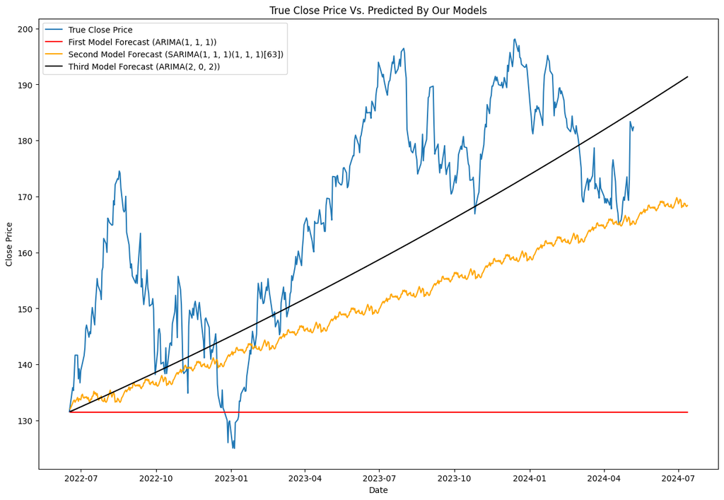

```python
# plotting
plt.figure(figsize=(15,10))
# plt.plot(pd.concat([pred_data['Close'],current_df['Close']],axis=0), label='True Price')
plt.plot(current_df['Close'], label='True Close Price')
# plt.plot(new_forecast.loc[:, 'yhat'], label='Prophet Prediction')
plt.plot(forecast_sarima0_values.index, forecast_sarima0_values, color='red', label='First Model Forecast (ARIMA(1, 1, 1))')
plt.plot(forecast_sarima1_values.index, forecast_sarima1_values, color='orange', label='Second Model Forecast (SARIMA(1, 1, 1)(1, 1, 1)[63])')
plt.plot(forecast_sarima2_values.index, forecast_sarima2_values, color='black', label='Third Model Forecast (ARIMA(2, 0, 2))')
plt.title('True Close Price Vs. Predicted By Our Models')
plt.xlabel('Date')
plt.ylabel('Close Price')
plt.legend()
plt.show()
```

# PART 3 - Incorporating an Exogenous Variable

Stock prices could be significanlty influenced by many indicators, including Apple products sales, new devices launches, GDP growth, interest rates and so on. After conducting research in exploring datasets that could be helpful for our data, we found that [NASDAQ-100 index](https://www.investopedia.com/terms/n/nasdaq100.asp) might be an interesting insight into predicting the Apple stock Close price. (The dataset we found regerading this index is partial in relation of the stock data we're currently working on, so we adjust the dataframes we're working on to fit the index's dataset)

```python
# not_clean_index_df = pd.read_csv('Jan20_NDXT.csv')  # Load NASDAQ-100 index dataset
# index_df = not_clean_index_df.dropna()
```

```python
# index_df.shape
```

```python
# index_df.columns
```

```python
# index_df['Date'] = pd.to_datetime(index_df['Date'])
# index_df.set_index('Date', inplace=True)
```

```python
# Merge the two dataframes
# merged_df = pd.merge(pred_data, index_df, left_index=True, right_index=True)
merged_df = pred_data.dropna()
```

```python
# Without SEASONALITY
from statsmodels.tsa.statespace.sarimax import SARIMAX
# Setting SARIMAX with the exogenous variable
data = merged_df['Close']
exog = merged_df['NDXT Close']
sarima2exog_model = SARIMAX(data, exog=exog,
                order=(2, 1, 2),
                enforce_stationarity=False,
                enforce_invertibility=False)
# enforce_stationarity=False and enforce_invertibility=False are
# helpful during model exploration, especially when the model diagnostics suggest non-invertibility or non-stationarity issues with the parameters
sarima2exog_results = sarima2exog_model.fit()
```

```python
print(sarima2exog_results.summary())
```

```
                               SARIMAX Results
==============================================================================
Dep. Variable:                  Close   No. Observations:                 2996
Model:               SARIMAX(2, 1, 2)   Log Likelihood                 -42.788
Date:                Thu, 09 May 2024   AIC                             97.576
Time:                        16:52:30   BIC                            133.598
Sample:                             0   HQIC                           110.535
                               - 2996
Covariance Type:                  opg
==============================================================================
                 coef    std err          z      P>|z|      [0.025      0.975]
------------------------------------------------------------------------------
NDXT Close     0.0076      0.000     43.062      0.000       0.007       0.008
ar.L1          0.0522      0.347      0.150      0.880      -0.627       0.732
ar.L2         -0.3291      0.233     -1.413      0.158      -0.786       0.127
ma.L1         -0.0076      0.349     -0.022      0.982      -0.691       0.676
ma.L2          0.2919      0.244      1.198      0.231      -0.186       0.769
sigma2         0.0603      0.001     96.801      0.000       0.059       0.062
===================================================================================
Ljung-Box (L1) (Q):                   0.00   Jarque-Bera (JB):             15607.17
Prob(Q):                              0.97   Prob(JB):                         0.00
Heteroskedasticity (H):              11.26   Skew:                             0.09
Prob(H) (two-sided):                  0.00   Kurtosis:                        14.19
===================================================================================

Warnings:
[1] Covariance matrix calculated using the outer product of gradients (complex-step).
```

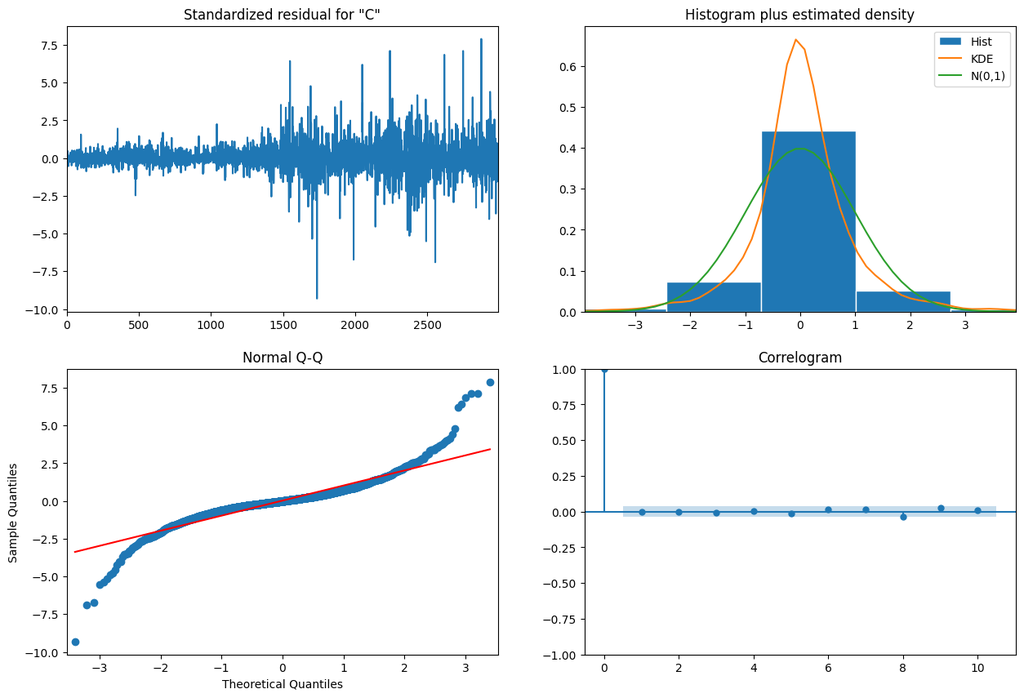

```python
# Plot residuals
sarima2exog_results.plot_diagnostics(figsize=(15, 10))
plt.show()
```

Revewing the diagnostics of the model with exogenous variable, we can see a huge difference compared to models we explored in the previous section, the log-likelihood (-42.788) is far more better, and AIC= 97 and BIC=133 is much better with a wide margin

```python
# With SEASONALITY
from statsmodels.tsa.statespace.sarimax import SARIMAX
# Setting SARIMAX according to the conclusions mentioned earlier
sarima1_model = SARIMAX(data, exog=exog,
                order=(1, 1, 1),
                seasonal_order=(1, 1, 1, 252//4),
                enforce_stationarity=False,
                enforce_invertibility=False)
# enforce_stationarity=False and enforce_invertibility=False are
# helpful during model exploration, especially when the model diagnostics suggest non-invertibility or non-stationarity issues with the parameters
sarima1_results = sarima1_model.fit(disp=True)
```

```python
print(sarima1_results.summary())
```

```
                                     SARIMAX Results
==========================================================================================
Dep. Variable:                              Close   No. Observations:                 2996
Model:             SARIMAX(1, 1, 1)x(1, 1, 1, 63)   Log Likelihood                -174.581
Date:                            Thu, 09 May 2024   AIC                            361.162
Time:                                    17:04:57   BIC                            396.928
Sample:                                         0   HQIC                           374.057
                                           - 2996
Covariance Type:                              opg
==============================================================================
                 coef    std err          z      P>|z|      [0.025      0.975]
------------------------------------------------------------------------------
NDXT Close     0.0076      0.000     41.968      0.000       0.007       0.008
ar.L1         -0.4342      0.254     -1.708      0.088      -0.932       0.064
ma.L1          0.4758      0.249      1.909      0.056      -0.013       0.964
ar.S.L63   -6.789e-06      0.008     -0.001      0.999      -0.015       0.015
ma.S.L63      -1.0079      0.030    -33.344      0.000      -1.067      -0.949
sigma2         0.0611      0.002     27.872      0.000       0.057       0.065
===================================================================================
Ljung-Box (L1) (Q):                   0.01   Jarque-Bera (JB):             13640.53
Prob(Q):                              0.94   Prob(JB):                         0.00
Heteroskedasticity (H):              10.61   Skew:                             0.08
Prob(H) (two-sided):                  0.00   Kurtosis:                        13.68
===================================================================================

Warnings:
[1] Covariance matrix calculated using the outer product of gradients (complex-step).
```

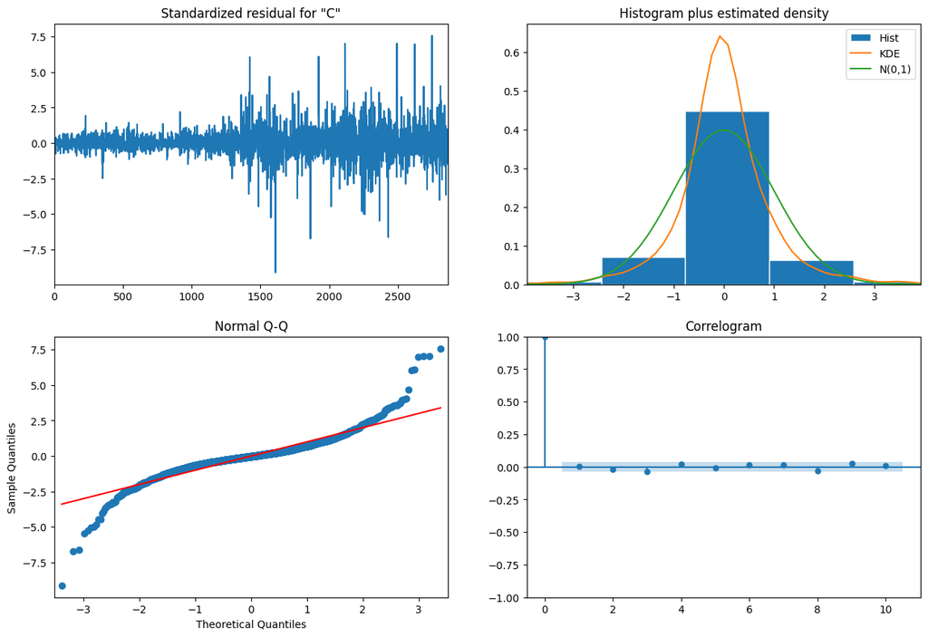

```python
# Plot residuals
sarima1_results.plot_diagnostics(figsize=(15, 10))
plt.show()
```

```
17:04:59 - cmdstanpy - INFO - Chain [1] start processing
17:05:00 - cmdstanpy - INFO - Chain [1] done processing
```

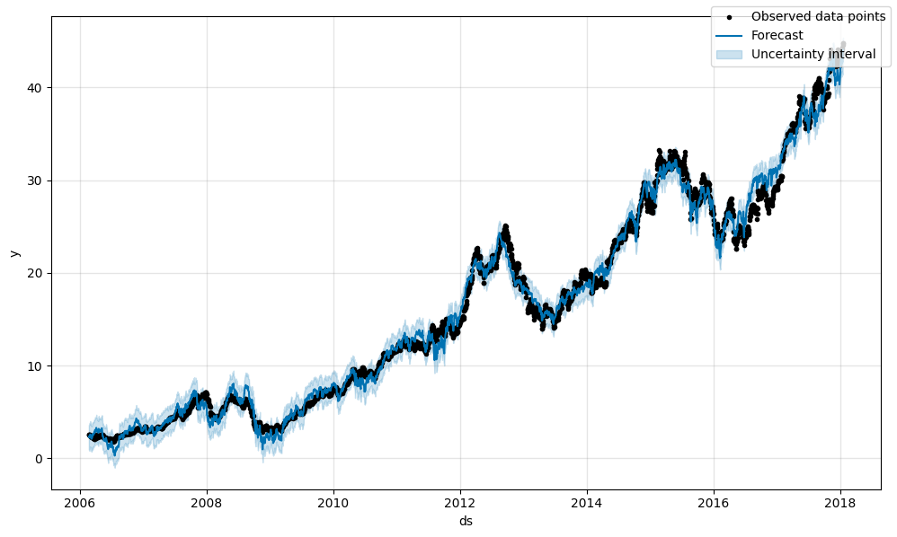

```python
# Assuming 'data' is the DataFrame with columns 'ds' (datetime), 'y' (target variable), and 'exog' (exogenous variable)
# Rename the columns to match Prophet's requirements

data = merged_df.reset_index().rename(columns={'Date': 'ds', 'Close': 'y', 'NDXT Close': 'exog'})

# Initialize Prophet model with exogenous regressor
prophet_model = Prophet()
prophet_model.add_regressor('exog')  # Add the exogenous variable to the model

# Fit the model to the data
prophet_model.fit(data)

forecast = prophet_model.predict(data)

# Plot the forecast
fig = prophet_model.plot(forecast)
fig.legend()
```

```python
# Get the in-sample predictions
in_sample_predictions = prophet_model.predict(data)

# Calculate residuals
residuals = data['y'] - in_sample_predictions['yhat']

# Calculate the effective number of parameters (p_eff)
p_eff = prophet_model.params['k'].shape[0]

# Calculate the log likelihood
log_likelihood = -0.5 * (np.log(2 * np.pi * residuals.std()) + (residuals ** 2 / residuals.var()).sum())

# Calculate the penalized log likelihood
penalized_log_likelihood = log_likelihood - p_eff

# Calculate WAIC
waic = -2 * penalized_log_likelihood + 2 * p_eff

print("WAIC:", waic)
```

```
WAIC: 3000.8945763968713
```